# GLM for guppies data

Rose McKeon** (2417024)

March 15th 2019

> Here goes nothing…

These data include frequency measures of male spot brightness in guppy populations that have been exposed to different environmental conditions, such as substrate and predation.

```r
head(guppy_counts)
```

```
## # A tibble: 6 x 6
## # Groups:   Spot.brightness, Day, Substrate, Predator [6]
##   Spot.brightness   Day Substrate  Predator   Predator.number Count
##             <int> <int> <fct>      <fct>                <int> <int>
## 1               1  1253 Sand       C.punctata              10     1
## 2               2     0 Sand       R.hartii                 5     1
## 3               2   502 Mud        C.punctata              10     2
## 4               2  1503 Sand       C.punctata              10     1
## 5               3   251 Mud        C.punctata              10     1
## 6               3   270 Vegetation C.punctata              10     2
```

Condensing the records into counts has made the data a little less balanced, but still adequate.

```r
summary(guppies$Predator)
```

```
##       None   R.hartii A.pulchens C.punctata
##       7178       6487       5811       5560
```

```r
summary(as.factor(guppies$Predator.number))
```

```
##    0    2    5   10
## 7178 6590 6035 5233
```

```r
summary(guppy_counts$Predator)
```

```
##       None   R.hartii A.pulchens C.punctata
##        585        765        921        915
```

```r
summary(as.factor(guppy_counts$Predator.number))
```

```
##   0   2   5  10
## 585 871 860 870
```

In every experiment spot brightness of all male guppies was recorded roughly every 250 days from 0 days to 1500. ## Exploratory plots

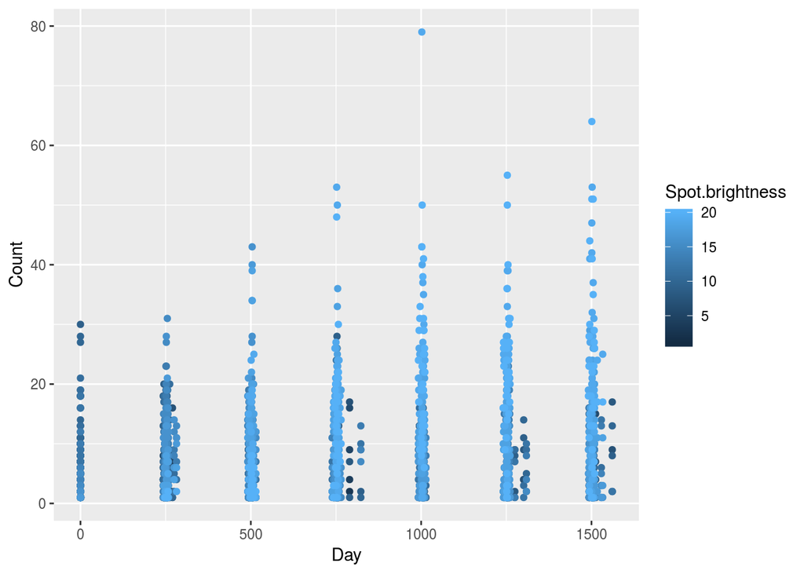

```r
qplot(
  Day, Count, data = guppy_counts,
  geom = "point",
  colour = Spot.brightness
)
```

There is definitely an effect of predator. There are far fewer bright spots recorded for some species especially.

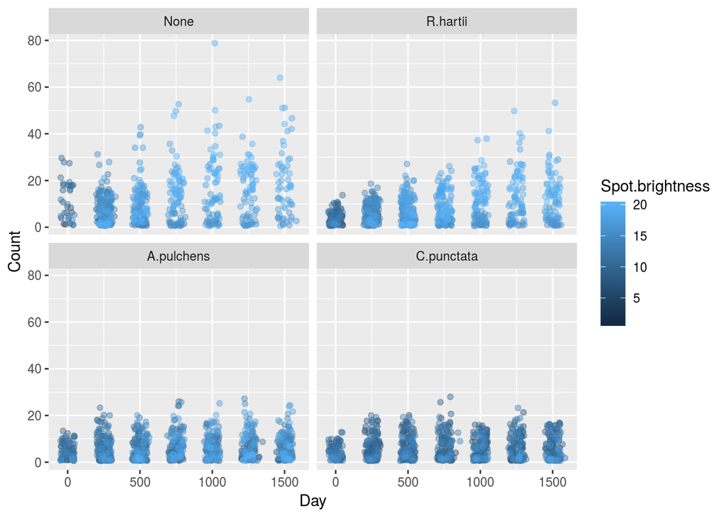

```r
ggplot(
  guppy_counts,
  aes(
    x = Day,
    y = Count,
    colour = Spot.brightness
  )
) + geom_jitter(
  width = 50,
  alpha = .4
) + facet_wrap(
  ~ Predator
)
```

There appears to be a similar relationship with predator number too. Though less strong. Perhaps due to records of R.hartii keeping bright spot records at higher density.

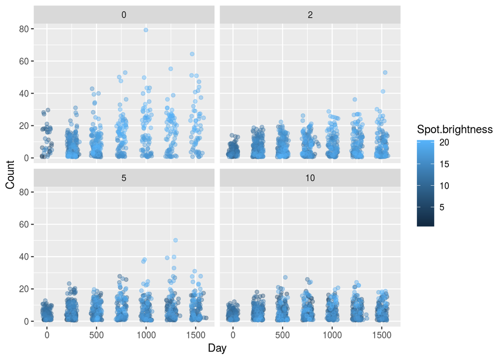

```r
ggplot(
  guppy_counts,
  aes(
    x = Day,
    y = Count,
    colour = Spot.brightness
  )
) + geom_jitter(
  width = 50,
  alpha = .4
) + facet_wrap(
  ~ Predator.number
)
```

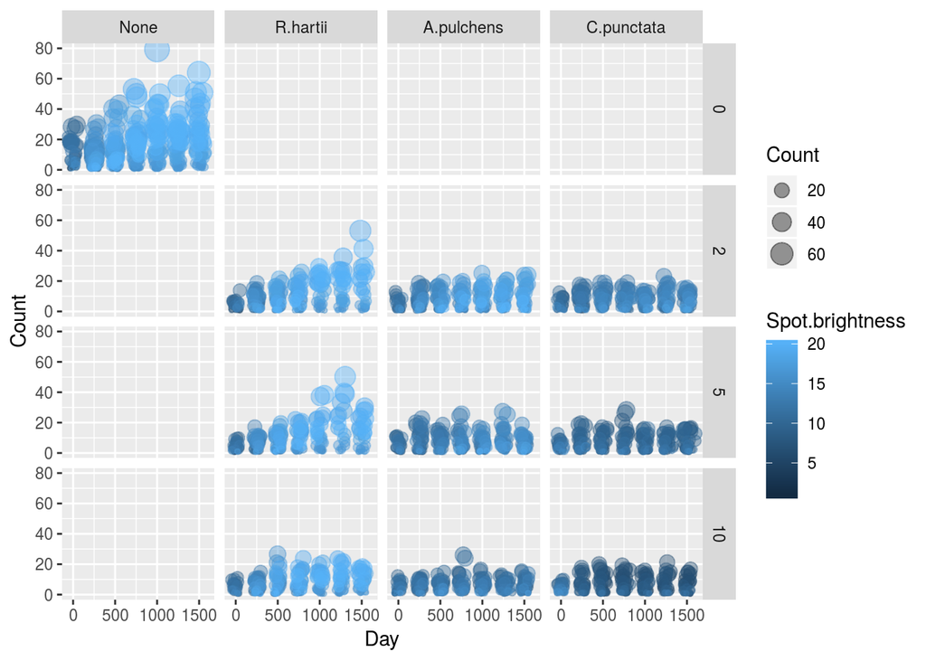

```r
ggplot(
  guppy_counts,
  aes(
    x = Day,
    y = Count,
    colour = Spot.brightness,
    size = Count
  )
) + geom_jitter(
  width = 50,
  alpha = .4
) + facet_grid(
  Predator.number ~ Predator
)
```

Not the best plot layout but we can see what’s happening really nicely. How about if we look at substrate too?

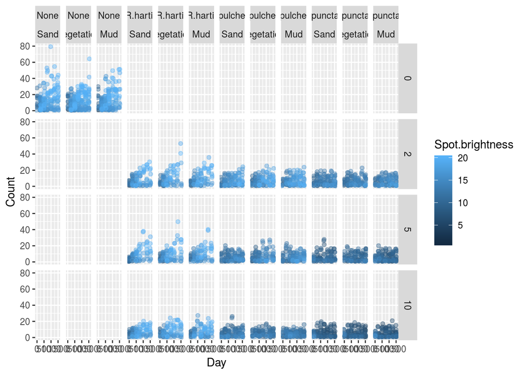

```r
ggplot(
  guppy_counts,
  aes(
    x = Day,
    y = Count,
    colour = Spot.brightness
  )
) + geom_jitter(
  width = 50,
  alpha = .4
) + facet_grid(
  Predator.number ~ Predator*Substrate
)
```

**Doesn’t look like there is much going on for substrate.**

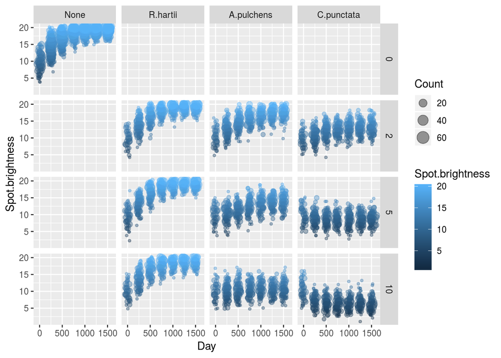

```r
ggplot(
  guppy_counts,
  aes(
    x = Day,
    y = Spot.brightness,
    colour = Spot.brightness,
    size = Count
  )
) + geom_jitter(
  width = 50,
  height = .25,
  alpha = .4
) + facet_grid(
  Predator.number ~ Predator
)
```

We can still plot the relationship this way around too, but **I’m not sure which is better**. This way shows the spread of data and the rise and fall is easy to read. But showing count on the Y axis makes the subtle differences for R.hartii more easy to read.

```r
# Business ------------------------------------
```

## Fitting the GLM

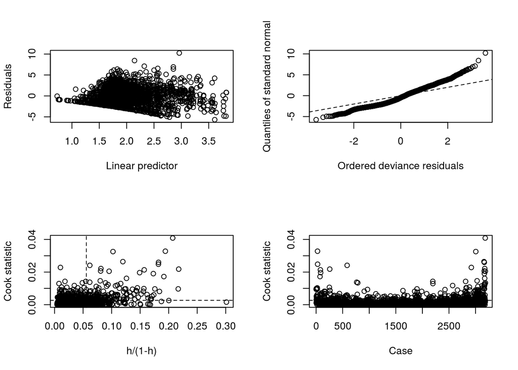

```r
fit1 <- glm(
  Count ~ Day*Spot.brightness*Predator*Predator.number*Substrate,
  data = guppy_counts,
  # we're interested in frequencies/counts
  family = "poisson"
)
glm.diag.plots(fit1)
```

**Terrible** Lot’s of points of high leverage in cooks plots and tails well off the line for residuals. We can probably get this better with simplification as we don’t expect substrate to be important.

```r
summary(fit1)
```

```
##
## Call:
## glm(formula = Count ~ Day * Spot.brightness * Predator * Predator.number *
##     Substrate, family = "poisson", data = guppy_counts)
##
## Deviance Residuals:
##     Min       1Q   Median       3Q      Max
## -5.5245  -1.8392  -0.4614   1.1190  10.1522
##
## Coefficients: (12 not defined because of singularities)
##                                                                              Estimate
## (Intercept)                                                                 2.590e+00
## Day                                                                        -7.074e-03
## Spot.brightness                                                            -3.264e-03
## PredatorR.hartii                                                           -1.822e+00
## PredatorA.pulchens                                                         -1.503e+00
## PredatorC.punctata                                                         -1.267e+00
## Predator.number                                                             1.065e-01
## SubstrateVegetation                                                         1.032e-01
## SubstrateMud                                                               -1.190e-01
## Day:Spot.brightness                                                         3.951e-04
## Day:PredatorR.hartii                                                        2.239e-03
## Day:PredatorA.pulchens                                                      6.623e-03
## Day:PredatorC.punctata                                                      7.664e-03
## Spot.brightness:PredatorR.hartii                                            9.733e-02
## Spot.brightness:PredatorA.pulchens                                          6.236e-02
## Spot.brightness:PredatorC.punctata                                          6.047e-02
## Day:Predator.number                                                        -9.308e-05
## Spot.brightness:Predator.number                                            -1.349e-02
## PredatorR.hartii:Predator.number                                           -4.549e-02
## PredatorA.pulchens:Predator.number                                         -2.899e-02
## PredatorC.punctata:Predator.number                                                 NA
## Day:SubstrateVegetation                                                    -3.647e-04
## Day:SubstrateMud                                                            7.672e-04
## Spot.brightness:SubstrateVegetation                                        -1.386e-02
## Spot.brightness:SubstrateMud                                               -1.825e-03
## PredatorR.hartii:SubstrateVegetation                                        1.074e+00
## PredatorA.pulchens:SubstrateVegetation                                      1.696e-01
## PredatorC.punctata:SubstrateVegetation                                     -4.050e-01
## PredatorR.hartii:SubstrateMud                                               7.750e-01
```

[output cut: 450 more lines]

```
## Day:Spot.brightness:PredatorA.pulchens:Predator.number:SubstrateVegetation
## Day:Spot.brightness:PredatorC.punctata:Predator.number:SubstrateVegetation
## Day:Spot.brightness:PredatorR.hartii:Predator.number:SubstrateMud
## Day:Spot.brightness:PredatorA.pulchens:Predator.number:SubstrateMud
## Day:Spot.brightness:PredatorC.punctata:Predator.number:SubstrateMud
## ---
## Signif. codes:  0 '***' 0.001 '**' 0.01 '*' 0.05 '.' 0.1 ' ' 1
##
## (Dispersion parameter for poisson family taken to be 1)
##
##     Null deviance: 19059  on 3185  degrees of freedom
## Residual deviance: 12316  on 3102  degrees of freedom
## AIC: 23636
##
## Number of Fisher Scoring iterations: 5
```

**Extreme over dispersion.** Very complex too. Let’s see if we can just take Substrate out all together as it seems not to do much. Plots didn’t show a clear relationship and the significant interactions don’t include substrate in the summary.

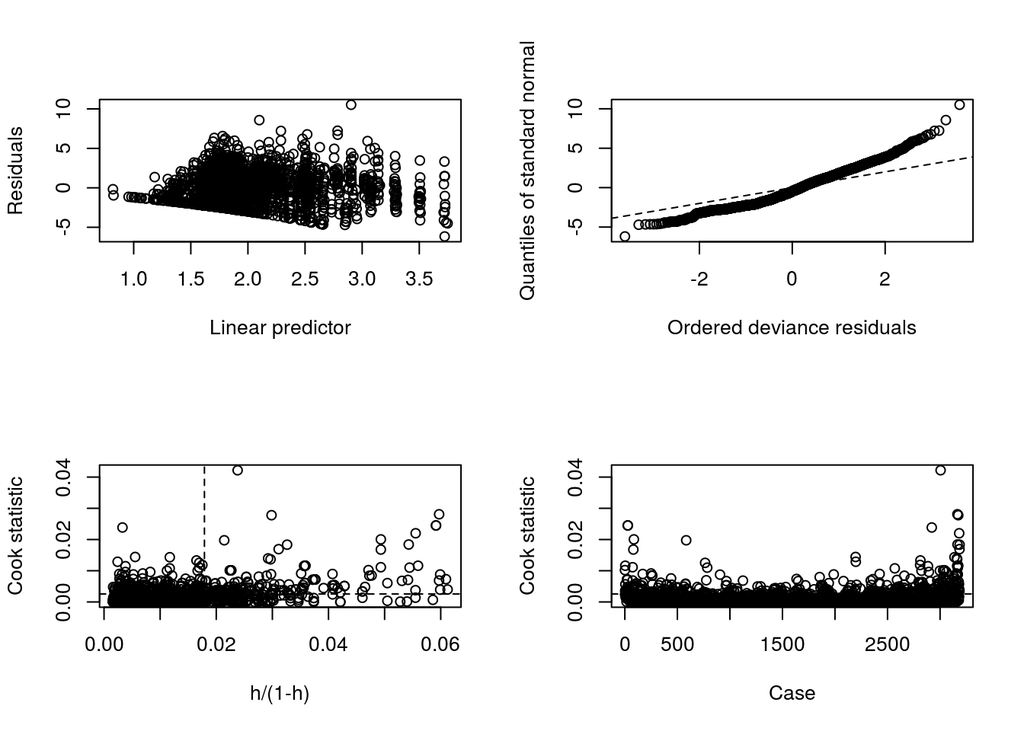

```r
fit2 <- glm(
  Count ~ Day*Spot.brightness*Predator*Predator.number,
  data = guppy_counts,
  family = "poisson"
)
glm.diag.plots(fit2) # not much better
```

```r
summary(fit2) # still huge over dispersion, but more significant coeffs.
```

```
##
## Call:
## glm(formula = Count ~ Day * Spot.brightness * Predator * Predator.number,
##     family = "poisson", data = guppy_counts)
##
## Deviance Residuals:
##     Min       1Q   Median       3Q      Max
## -6.1034  -1.8418  -0.4717   1.1164  10.4929
##
## Coefficients: (4 not defined because of singularities)
##                                                          Estimate
## (Intercept)                                             2.589e+00
## Day                                                    -6.977e-03
## Spot.brightness                                        -8.465e-03
## PredatorR.hartii                                       -1.269e+00
## PredatorA.pulchens                                     -1.220e+00
## PredatorC.punctata                                     -1.201e+00
## Predator.number                                         6.630e-02
## Day:Spot.brightness                                     3.922e-04
## Day:PredatorR.hartii                                    2.024e-03
## Day:PredatorA.pulchens                                  6.721e-03
## Day:PredatorC.punctata                                  7.398e-03
## Spot.brightness:PredatorR.hartii                        5.583e-02
## Spot.brightness:PredatorA.pulchens                      4.877e-02
## Spot.brightness:PredatorC.punctata                      5.649e-02
## Day:Predator.number                                    -3.963e-05
## Spot.brightness:Predator.number                        -9.770e-03
## PredatorR.hartii:Predator.number                       -5.686e-02
## PredatorA.pulchens:Predator.number                     -4.184e-02
## PredatorC.punctata:Predator.number                             NA
## Day:Spot.brightness:PredatorR.hartii                   -9.856e-05
## Day:Spot.brightness:PredatorA.pulchens                 -3.666e-04
## Day:Spot.brightness:PredatorC.punctata                 -4.245e-04
## Day:Spot.brightness:Predator.number                     3.477e-06
## Day:PredatorR.hartii:Predator.number                    1.698e-04
## Day:PredatorA.pulchens:Predator.number                  9.138e-05
## Day:PredatorC.punctata:Predator.number                         NA
## Spot.brightness:PredatorR.hartii:Predator.number        8.258e-03
## Spot.brightness:PredatorA.pulchens:Predator.number      5.658e-03
## Spot.brightness:PredatorC.punctata:Predator.number             NA
```

[output cut: 64 more lines]

```
## Spot.brightness:PredatorA.pulchens:Predator.number     0.106889
## Spot.brightness:PredatorC.punctata:Predator.number           NA
## Day:Spot.brightness:PredatorR.hartii:Predator.number   0.005032 **
## Day:Spot.brightness:PredatorA.pulchens:Predator.number 0.051067 .
## Day:Spot.brightness:PredatorC.punctata:Predator.number       NA
## ---
## Signif. codes:  0 '***' 0.001 '**' 0.01 '*' 0.05 '.' 0.1 ' ' 1
##
## (Dispersion parameter for poisson family taken to be 1)
##
##     Null deviance: 19059  on 3185  degrees of freedom
## Residual deviance: 12474  on 3158  degrees of freedom
## AIC: 23683
##
## Number of Fisher Scoring iterations: 5
```

```r
anova(fit1, fit2, test = "Chi")
```

```
## Analysis of Deviance Table
##
## Model 1: Count ~ Day * Spot.brightness * Predator * Predator.number *
##     Substrate
## Model 2: Count ~ Day * Spot.brightness * Predator * Predator.number
##   Resid. Df Resid. Dev  Df Deviance  Pr(>Chi)
## 1      3102      12316
## 2      3158      12474 -56  -158.72 9.187e-12 ***
## ---
## Signif. codes:  0 '***' 0.001 '**' 0.01 '*' 0.05 '.' 0.1 ' ' 1
```

**Removal not valid.**

OK. We’ll have to take this slower. Let’s just take out the interaction, but keep the main effect.

```r
# update method not working.
fit3 <- glm(
  Count ~ Day*Spot.brightness*Predator*Predator.number+Substrate,
  data = guppy_counts,
  family = "poisson"
)
anova(fit1, fit3, test = "Chi")
```

```
## Analysis of Deviance Table
##
## Model 1: Count ~ Day * Spot.brightness * Predator * Predator.number *
##     Substrate
## Model 2: Count ~ Day * Spot.brightness * Predator * Predator.number +
##     Substrate
##   Resid. Df Resid. Dev  Df Deviance  Pr(>Chi)
## 1      3102      12316
## 2      3156      12473 -54  -157.13 5.261e-12 ***
## ---
## Signif. codes:  0 '***' 0.001 '**' 0.01 '*' 0.05 '.' 0.1 ' ' 1
```

**Removal not valid :(** Will we be able to take out anything?

```r
fit4 <- glm(
  Count ~ Day*Spot.brightness*Predator+Predator.number*Substrate,
  data = guppy_counts,
  family = "poisson"
)
anova(fit1, fit4, test = "Chi")
```

```
## Analysis of Deviance Table
##
## Model 1: Count ~ Day * Spot.brightness * Predator * Predator.number *
##     Substrate
## Model 2: Count ~ Day * Spot.brightness * Predator + Predator.number *
##     Substrate
##   Resid. Df Resid. Dev  Df Deviance  Pr(>Chi)
## 1      3102      12316
## 2      3165      12542 -63  -226.97 < 2.2e-16 ***
## ---
## Signif. codes:  0 '***' 0.001 '**' 0.01 '*' 0.05 '.' 0.1 ' ' 1
```

**Nope**.

```r
fit5 <- glm(
  Count ~ Day*Spot.brightness+Predator*Predator.number*Substrate,
  data = guppy_counts,
  family = "poisson"
)
anova(fit1, fit5, test = "Chi")
```

```
## Analysis of Deviance Table
##
## Model 1: Count ~ Day * Spot.brightness * Predator * Predator.number *
##     Substrate
## Model 2: Count ~ Day * Spot.brightness + Predator * Predator.number *
##     Substrate
##   Resid. Df Resid. Dev  Df Deviance  Pr(>Chi)
## 1      3102      12316
## 2      3162      14754 -60  -2438.7 < 2.2e-16 ***
## ---
## Signif. codes:  0 '***' 0.001 '**' 0.01 '*' 0.05 '.' 0.1 ' ' 1
```

**Nope**.

```r
fit6 <- glm(
  Count ~ Day+Spot.brightness*Predator*Predator.number*Substrate,
  data = guppy_counts,
  family = "poisson"
)
anova(fit1, fit6, test = "Chi")
```

```
## Analysis of Deviance Table
##
## Model 1: Count ~ Day * Spot.brightness * Predator * Predator.number *
##     Substrate
## Model 2: Count ~ Day + Spot.brightness * Predator * Predator.number *
##     Substrate
##   Resid. Df Resid. Dev  Df Deviance  Pr(>Chi)
## 1      3102      12316
## 2      3143      14180 -41  -1864.8 < 2.2e-16 ***
## ---
## Signif. codes:  0 '***' 0.001 '**' 0.01 '*' 0.05 '.' 0.1 ' ' 1
```

**Nope**. > None of the interactions can be removed.

## Can we do something about over dispersion?

Let’s try quasipoisson

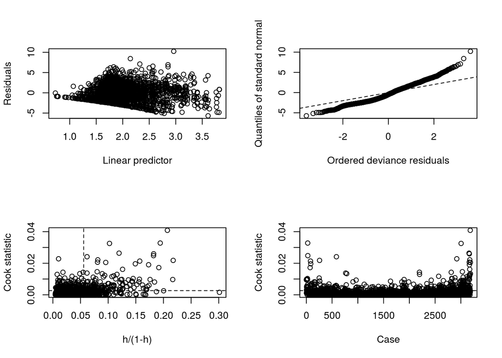

```r
fit7 <- glm(
  Count ~ Day*Spot.brightness*Predator*Predator.number*Substrate,
  data = guppy_counts,
  # let's try and account for overdispersion
  family = "quasipoisson"
)
# dianostics
glm.diag.plots(fit7) # Still not great
```

```r
summary(fit7) # overdispersion estimate = 4.069
```

```
##
## Call:
## glm(formula = Count ~ Day * Spot.brightness * Predator * Predator.number *
##     Substrate, family = "quasipoisson", data = guppy_counts)
##
## Deviance Residuals:
##     Min       1Q   Median       3Q      Max
## -5.5245  -1.8392  -0.4614   1.1190  10.1522
##
## Coefficients: (12 not defined because of singularities)
##                                                                              Estimate
## (Intercept)                                                                 2.590e+00
## Day                                                                        -7.074e-03
## Spot.brightness                                                            -3.264e-03
## PredatorR.hartii                                                           -1.822e+00
## PredatorA.pulchens                                                         -1.503e+00
## PredatorC.punctata                                                         -1.267e+00
## Predator.number                                                             1.065e-01
## SubstrateVegetation                                                         1.032e-01
## SubstrateMud                                                               -1.190e-01
## Day:Spot.brightness                                                         3.951e-04
## Day:PredatorR.hartii                                                        2.239e-03
## Day:PredatorA.pulchens                                                      6.623e-03
## Day:PredatorC.punctata                                                      7.664e-03
## Spot.brightness:PredatorR.hartii                                            9.733e-02
## Spot.brightness:PredatorA.pulchens                                          6.236e-02
## Spot.brightness:PredatorC.punctata                                          6.047e-02
## Day:Predator.number                                                        -9.308e-05
## Spot.brightness:Predator.number                                            -1.349e-02
## PredatorR.hartii:Predator.number                                           -4.549e-02
## PredatorA.pulchens:Predator.number                                         -2.899e-02
## PredatorC.punctata:Predator.number                                                 NA
## Day:SubstrateVegetation                                                    -3.647e-04
## Day:SubstrateMud                                                            7.672e-04
## Spot.brightness:SubstrateVegetation                                        -1.386e-02
## Spot.brightness:SubstrateMud                                               -1.825e-03
## PredatorR.hartii:SubstrateVegetation                                        1.074e+00
## PredatorA.pulchens:SubstrateVegetation                                      1.696e-01
## PredatorC.punctata:SubstrateVegetation                                     -4.050e-01
## PredatorR.hartii:SubstrateMud                                               7.750e-01
```

[output cut: 450 more lines]

```
## Day:Spot.brightness:PredatorA.pulchens:Predator.number:SubstrateVegetation
## Day:Spot.brightness:PredatorC.punctata:Predator.number:SubstrateVegetation
## Day:Spot.brightness:PredatorR.hartii:Predator.number:SubstrateMud
## Day:Spot.brightness:PredatorA.pulchens:Predator.number:SubstrateMud
## Day:Spot.brightness:PredatorC.punctata:Predator.number:SubstrateMud
## ---
## Signif. codes:  0 '***' 0.001 '**' 0.01 '*' 0.05 '.' 0.1 ' ' 1
##
## (Dispersion parameter for quasipoisson family taken to be 4.069274)
##
##     Null deviance: 19059  on 3185  degrees of freedom
## Residual deviance: 12316  on 3102  degrees of freedom
## AIC: NA
##
## Number of Fisher Scoring iterations: 5
```

**The variance is ~4 times larger than the mean.**

```r
# I was missing the comma! damn. OK let's try one more time to simplify.
fit8 <- update(fit7, ~. -Day:Substrate)
anova(fit7, fit8, test = "Chi")
```

```
## Analysis of Deviance Table
##
## Model 1: Count ~ Day * Spot.brightness * Predator * Predator.number *
##     Substrate
## Model 2: Count ~ Day + Spot.brightness + Predator + Predator.number +
##     Substrate + Day:Spot.brightness + Day:Predator + Spot.brightness:Predator +
##     Day:Predator.number + Spot.brightness:Predator.number + Predator:Predator.number +
##     Spot.brightness:Substrate + Predator:Substrate + Predator.number:Substrate +
##     Day:Spot.brightness:Predator + Day:Spot.brightness:Predator.number +
##     Day:Predator:Predator.number + Spot.brightness:Predator:Predator.number +
##     Day:Spot.brightness:Substrate + Day:Predator:Substrate +
##     Spot.brightness:Predator:Substrate + Day:Predator.number:Substrate +
##     Spot.brightness:Predator.number:Substrate + Predator:Predator.number:Substrate +
##     Day:Spot.brightness:Predator:Predator.number + Day:Spot.brightness:Predator:Substrate +
##     Day:Spot.brightness:Predator.number:Substrate + Day:Predator:Predator.number:Substrate +
##     Spot.brightness:Predator:Predator.number:Substrate + Day:Spot.brightness:Predator:Predator.number:Substrate
##   Resid. Df Resid. Dev Df Deviance Pr(>Chi)
## 1      3102      12316
## 2      3104      12321 -2  -5.1055    0.534
```

**Removal VALID**

```r
fit9 <- update(fit8, ~. -Spot.brightness:Substrate)
anova(fit8, fit9, test = "Chi")
```

```
## Analysis of Deviance Table
##
## Model 1: Count ~ Day + Spot.brightness + Predator + Predator.number +
##     Substrate + Day:Spot.brightness + Day:Predator + Spot.brightness:Predator +
##     Day:Predator.number + Spot.brightness:Predator.number + Predator:Predator.number +
##     Spot.brightness:Substrate + Predator:Substrate + Predator.number:Substrate +
##     Day:Spot.brightness:Predator + Day:Spot.brightness:Predator.number +
##     Day:Predator:Predator.number + Spot.brightness:Predator:Predator.number +
##     Day:Spot.brightness:Substrate + Day:Predator:Substrate +
##     Spot.brightness:Predator:Substrate + Day:Predator.number:Substrate +
##     Spot.brightness:Predator.number:Substrate + Predator:Predator.number:Substrate +
##     Day:Spot.brightness:Predator:Predator.number + Day:Spot.brightness:Predator:Substrate +
##     Day:Spot.brightness:Predator.number:Substrate + Day:Predator:Predator.number:Substrate +
##     Spot.brightness:Predator:Predator.number:Substrate + Day:Spot.brightness:Predator:Predator.number:Substrate
## Model 2: Count ~ Day + Spot.brightness + Predator + Predator.number +
##     Substrate + Day:Spot.brightness + Day:Predator + Spot.brightness:Predator +
##     Day:Predator.number + Spot.brightness:Predator.number + Predator:Predator.number +
##     Predator:Substrate + Predator.number:Substrate + Day:Spot.brightness:Predator +
##     Day:Spot.brightness:Predator.number + Day:Predator:Predator.number +
##     Spot.brightness:Predator:Predator.number + Day:Spot.brightness:Substrate +
##     Day:Predator:Substrate + Spot.brightness:Predator:Substrate +
##     Day:Predator.number:Substrate + Spot.brightness:Predator.number:Substrate +
##     Predator:Predator.number:Substrate + Day:Spot.brightness:Predator:Predator.number +
##     Day:Spot.brightness:Predator:Substrate + Day:Spot.brightness:Predator.number:Substrate +
##     Day:Predator:Predator.number:Substrate + Spot.brightness:Predator:Predator.number:Substrate +
##     Day:Spot.brightness:Predator:Predator.number:Substrate
##   Resid. Df Resid. Dev Df Deviance Pr(>Chi)
## 1      3104      12321
## 2      3106      12322 -2 -0.79561   0.9069
```

**Removal VALID**

```r
fit10 <- update(fit9, ~. -Predator:Substrate)
anova(fit9, fit10, test = "Chi")
```

```
## Analysis of Deviance Table
##
## Model 1: Count ~ Day + Spot.brightness + Predator + Predator.number +
##     Substrate + Day:Spot.brightness + Day:Predator + Spot.brightness:Predator +
##     Day:Predator.number + Spot.brightness:Predator.number + Predator:Predator.number +
##     Predator:Substrate + Predator.number:Substrate + Day:Spot.brightness:Predator +
##     Day:Spot.brightness:Predator.number + Day:Predator:Predator.number +
##     Spot.brightness:Predator:Predator.number + Day:Spot.brightness:Substrate +
##     Day:Predator:Substrate + Spot.brightness:Predator:Substrate +
##     Day:Predator.number:Substrate + Spot.brightness:Predator.number:Substrate +
##     Predator:Predator.number:Substrate + Day:Spot.brightness:Predator:Predator.number +
##     Day:Spot.brightness:Predator:Substrate + Day:Spot.brightness:Predator.number:Substrate +
##     Day:Predator:Predator.number:Substrate + Spot.brightness:Predator:Predator.number:Substrate +
##     Day:Spot.brightness:Predator:Predator.number:Substrate
## Model 2: Count ~ Day + Spot.brightness + Predator + Predator.number +
##     Substrate + Day:Spot.brightness + Day:Predator + Spot.brightness:Predator +
##     Day:Predator.number + Spot.brightness:Predator.number + Predator:Predator.number +
##     Predator.number:Substrate + Day:Spot.brightness:Predator +
##     Day:Spot.brightness:Predator.number + Day:Predator:Predator.number +
##     Spot.brightness:Predator:Predator.number + Day:Spot.brightness:Substrate +
##     Day:Predator:Substrate + Spot.brightness:Predator:Substrate +
##     Day:Predator.number:Substrate + Spot.brightness:Predator.number:Substrate +
##     Predator:Predator.number:Substrate + Day:Spot.brightness:Predator:Predator.number +
##     Day:Spot.brightness:Predator:Substrate + Day:Spot.brightness:Predator.number:Substrate +
##     Day:Predator:Predator.number:Substrate + Spot.brightness:Predator:Predator.number:Substrate +
##     Day:Spot.brightness:Predator:Predator.number:Substrate
##   Resid. Df Resid. Dev Df Deviance Pr(>Chi)
## 1      3106      12322
## 2      3112      12336 -6  -14.015   0.7513
```

**Removal VALID**

```r
fit11 <- update(fit10, ~. -Predator.number:Substrate)
anova(fit10, fit11, test = "Chi")
```

```
## Analysis of Deviance Table
##
## Model 1: Count ~ Day + Spot.brightness + Predator + Predator.number +
##     Substrate + Day:Spot.brightness + Day:Predator + Spot.brightness:Predator +
##     Day:Predator.number + Spot.brightness:Predator.number + Predator:Predator.number +
##     Predator.number:Substrate + Day:Spot.brightness:Predator +
##     Day:Spot.brightness:Predator.number + Day:Predator:Predator.number +
##     Spot.brightness:Predator:Predator.number + Day:Spot.brightness:Substrate +
##     Day:Predator:Substrate + Spot.brightness:Predator:Substrate +
##     Day:Predator.number:Substrate + Spot.brightness:Predator.number:Substrate +
##     Predator:Predator.number:Substrate + Day:Spot.brightness:Predator:Predator.number +
##     Day:Spot.brightness:Predator:Substrate + Day:Spot.brightness:Predator.number:Substrate +
##     Day:Predator:Predator.number:Substrate + Spot.brightness:Predator:Predator.number:Substrate +
##     Day:Spot.brightness:Predator:Predator.number:Substrate
## Model 2: Count ~ Day + Spot.brightness + Predator + Predator.number +
##     Substrate + Day:Spot.brightness + Day:Predator + Spot.brightness:Predator +
##     Day:Predator.number + Spot.brightness:Predator.number + Predator:Predator.number +
##     Day:Spot.brightness:Predator + Day:Spot.brightness:Predator.number +
##     Day:Predator:Predator.number + Spot.brightness:Predator:Predator.number +
##     Day:Spot.brightness:Substrate + Day:Predator:Substrate +
##     Spot.brightness:Predator:Substrate + Day:Predator.number:Substrate +
##     Spot.brightness:Predator.number:Substrate + Predator:Predator.number:Substrate +
##     Day:Spot.brightness:Predator:Predator.number + Day:Spot.brightness:Predator:Substrate +
##     Day:Spot.brightness:Predator.number:Substrate + Day:Predator:Predator.number:Substrate +
##     Spot.brightness:Predator:Predator.number:Substrate + Day:Spot.brightness:Predator:Predator.number:Substrate
##   Resid. Df Resid. Dev Df Deviance Pr(>Chi)
## 1      3112      12336
## 2      3112      12336  0        0
```

**Removal VALID**

```r
fit12 <- update(
  fit11,
  ~. -Day:Spot.brightness:Predator:Predator.number:Substrate
)
anova(fit11, fit12, test = "Chi")
```

```
## Analysis of Deviance Table
##
## Model 1: Count ~ Day + Spot.brightness + Predator + Predator.number +
##     Substrate + Day:Spot.brightness + Day:Predator + Spot.brightness:Predator +
##     Day:Predator.number + Spot.brightness:Predator.number + Predator:Predator.number +
##     Day:Spot.brightness:Predator + Day:Spot.brightness:Predator.number +
##     Day:Predator:Predator.number + Spot.brightness:Predator:Predator.number +
##     Day:Spot.brightness:Substrate + Day:Predator:Substrate +
##     Spot.brightness:Predator:Substrate + Day:Predator.number:Substrate +
##     Spot.brightness:Predator.number:Substrate + Predator:Predator.number:Substrate +
##     Day:Spot.brightness:Predator:Predator.number + Day:Spot.brightness:Predator:Substrate +
##     Day:Spot.brightness:Predator.number:Substrate + Day:Predator:Predator.number:Substrate +
##     Spot.brightness:Predator:Predator.number:Substrate + Day:Spot.brightness:Predator:Predator.number:Substrate
## Model 2: Count ~ Day + Spot.brightness + Predator + Predator.number +
##     Substrate + Day:Spot.brightness + Day:Predator + Spot.brightness:Predator +
##     Day:Predator.number + Spot.brightness:Predator.number + Predator:Predator.number +
##     Day:Spot.brightness:Predator + Day:Spot.brightness:Predator.number +
##     Day:Predator:Predator.number + Spot.brightness:Predator:Predator.number +
##     Day:Spot.brightness:Substrate + Day:Predator:Substrate +
##     Spot.brightness:Predator:Substrate + Day:Predator.number:Substrate +
##     Spot.brightness:Predator.number:Substrate + Predator:Predator.number:Substrate +
##     Day:Spot.brightness:Predator:Predator.number + Day:Spot.brightness:Predator:Substrate +
##     Day:Spot.brightness:Predator.number:Substrate + Day:Predator:Predator.number:Substrate +
##     Spot.brightness:Predator:Predator.number:Substrate
##   Resid. Df Resid. Dev Df Deviance Pr(>Chi)
## 1      3112      12336
## 2      3116      12348 -4  -12.693   0.5377
```

**Removal VALID**

```r
fit13 <- update(
  fit12,
  ~. -Spot.brightness:Predator:Predator.number:Substrate
)
anova(fit12, fit13, test = "Chi")
```

```
## Analysis of Deviance Table
##
## Model 1: Count ~ Day + Spot.brightness + Predator + Predator.number +
##     Substrate + Day:Spot.brightness + Day:Predator + Spot.brightness:Predator +
##     Day:Predator.number + Spot.brightness:Predator.number + Predator:Predator.number +
##     Day:Spot.brightness:Predator + Day:Spot.brightness:Predator.number +
##     Day:Predator:Predator.number + Spot.brightness:Predator:Predator.number +
##     Day:Spot.brightness:Substrate + Day:Predator:Substrate +
##     Spot.brightness:Predator:Substrate + Day:Predator.number:Substrate +
##     Spot.brightness:Predator.number:Substrate + Predator:Predator.number:Substrate +
##     Day:Spot.brightness:Predator:Predator.number + Day:Spot.brightness:Predator:Substrate +
##     Day:Spot.brightness:Predator.number:Substrate + Day:Predator:Predator.number:Substrate +
##     Spot.brightness:Predator:Predator.number:Substrate
## Model 2: Count ~ Day + Spot.brightness + Predator + Predator.number +
##     Substrate + Day:Spot.brightness + Day:Predator + Spot.brightness:Predator +
##     Day:Predator.number + Spot.brightness:Predator.number + Predator:Predator.number +
##     Day:Spot.brightness:Predator + Day:Spot.brightness:Predator.number +
##     Day:Predator:Predator.number + Spot.brightness:Predator:Predator.number +
##     Day:Spot.brightness:Substrate + Day:Predator:Substrate +
##     Spot.brightness:Predator:Substrate + Day:Predator.number:Substrate +
##     Spot.brightness:Predator.number:Substrate + Predator:Predator.number:Substrate +
##     Day:Spot.brightness:Predator:Predator.number + Day:Spot.brightness:Predator:Substrate +
##     Day:Spot.brightness:Predator.number:Substrate + Day:Predator:Predator.number:Substrate
##   Resid. Df Resid. Dev Df Deviance Pr(>Chi)
## 1      3116      12348
## 2      3120      12354 -4  -5.5527   0.8503
```

**Removal VALID**

```r
fit14 <- update(
  fit13,
  ~. -Predator:Predator.number:Substrate
)
anova(fit13, fit14, test = "Chi")
```

```
## Analysis of Deviance Table
##
## Model 1: Count ~ Day + Spot.brightness + Predator + Predator.number +
##     Substrate + Day:Spot.brightness + Day:Predator + Spot.brightness:Predator +
##     Day:Predator.number + Spot.brightness:Predator.number + Predator:Predator.number +
##     Day:Spot.brightness:Predator + Day:Spot.brightness:Predator.number +
##     Day:Predator:Predator.number + Spot.brightness:Predator:Predator.number +
##     Day:Spot.brightness:Substrate + Day:Predator:Substrate +
##     Spot.brightness:Predator:Substrate + Day:Predator.number:Substrate +
##     Spot.brightness:Predator.number:Substrate + Predator:Predator.number:Substrate +
##     Day:Spot.brightness:Predator:Predator.number + Day:Spot.brightness:Predator:Substrate +
##     Day:Spot.brightness:Predator.number:Substrate + Day:Predator:Predator.number:Substrate
## Model 2: Count ~ Day + Spot.brightness + Predator + Predator.number +
##     Substrate + Day:Spot.brightness + Day:Predator + Spot.brightness:Predator +
##     Day:Predator.number + Spot.brightness:Predator.number + Predator:Predator.number +
##     Day:Spot.brightness:Predator + Day:Spot.brightness:Predator.number +
##     Day:Predator:Predator.number + Spot.brightness:Predator:Predator.number +
##     Day:Spot.brightness:Substrate + Day:Predator:Substrate +
##     Spot.brightness:Predator:Substrate + Day:Predator.number:Substrate +
##     Spot.brightness:Predator.number:Substrate + Day:Spot.brightness:Predator:Predator.number +
##     Day:Spot.brightness:Predator:Substrate + Day:Spot.brightness:Predator.number:Substrate +
##     Day:Predator:Predator.number:Substrate
##   Resid. Df Resid. Dev Df Deviance Pr(>Chi)
## 1      3120      12354
## 2      3126      12363 -6  -9.5357   0.8853
```

**Removal VALID**

```r
fit15 <- update(
  fit14,
  ~. -Day:Predator:Predator.number:Substrate
)
anova(fit14, fit15, test = "Chi")
```

```
## Analysis of Deviance Table
##
## Model 1: Count ~ Day + Spot.brightness + Predator + Predator.number +
##     Substrate + Day:Spot.brightness + Day:Predator + Spot.brightness:Predator +
##     Day:Predator.number + Spot.brightness:Predator.number + Predator:Predator.number +
##     Day:Spot.brightness:Predator + Day:Spot.brightness:Predator.number +
##     Day:Predator:Predator.number + Spot.brightness:Predator:Predator.number +
##     Day:Spot.brightness:Substrate + Day:Predator:Substrate +
##     Spot.brightness:Predator:Substrate + Day:Predator.number:Substrate +
##     Spot.brightness:Predator.number:Substrate + Day:Spot.brightness:Predator:Predator.number +
##     Day:Spot.brightness:Predator:Substrate + Day:Spot.brightness:Predator.number:Substrate +
##     Day:Predator:Predator.number:Substrate
## Model 2: Count ~ Day + Spot.brightness + Predator + Predator.number +
##     Substrate + Day:Spot.brightness + Day:Predator + Spot.brightness:Predator +
##     Day:Predator.number + Spot.brightness:Predator.number + Predator:Predator.number +
##     Day:Spot.brightness:Predator + Day:Spot.brightness:Predator.number +
##     Day:Predator:Predator.number + Spot.brightness:Predator:Predator.number +
##     Day:Spot.brightness:Substrate + Day:Predator:Substrate +
##     Spot.brightness:Predator:Substrate + Day:Predator.number:Substrate +
##     Spot.brightness:Predator.number:Substrate + Day:Spot.brightness:Predator:Predator.number +
##     Day:Spot.brightness:Predator:Substrate + Day:Spot.brightness:Predator.number:Substrate
##   Resid. Df Resid. Dev Df Deviance Pr(>Chi)
## 1      3126      12363
## 2      3130      12368 -4  -4.2414    0.903
```

**Removal VALID**

```r
fit16 <- update(
  fit15,
  ~. -Day:Spot.brightness:Predator.number:Substrate
)
anova(fit15, fit16, test = "Chi")
```

```
## Analysis of Deviance Table
##
## Model 1: Count ~ Day + Spot.brightness + Predator + Predator.number +
##     Substrate + Day:Spot.brightness + Day:Predator + Spot.brightness:Predator +
##     Day:Predator.number + Spot.brightness:Predator.number + Predator:Predator.number +
##     Day:Spot.brightness:Predator + Day:Spot.brightness:Predator.number +
##     Day:Predator:Predator.number + Spot.brightness:Predator:Predator.number +
##     Day:Spot.brightness:Substrate + Day:Predator:Substrate +
##     Spot.brightness:Predator:Substrate + Day:Predator.number:Substrate +
##     Spot.brightness:Predator.number:Substrate + Day:Spot.brightness:Predator:Predator.number +
##     Day:Spot.brightness:Predator:Substrate + Day:Spot.brightness:Predator.number:Substrate
## Model 2: Count ~ Day + Spot.brightness + Predator + Predator.number +
##     Substrate + Day:Spot.brightness + Day:Predator + Spot.brightness:Predator +
##     Day:Predator.number + Spot.brightness:Predator.number + Predator:Predator.number +
##     Day:Spot.brightness:Predator + Day:Spot.brightness:Predator.number +
##     Day:Predator:Predator.number + Spot.brightness:Predator:Predator.number +
##     Day:Spot.brightness:Substrate + Day:Predator:Substrate +
##     Spot.brightness:Predator:Substrate + Day:Predator.number:Substrate +
##     Spot.brightness:Predator.number:Substrate + Day:Spot.brightness:Predator:Predator.number +
##     Day:Spot.brightness:Predator:Substrate
##   Resid. Df Resid. Dev Df Deviance Pr(>Chi)
## 1      3130      12368
## 2      3132      12368 -2  -1.0254   0.8814
```

**Removal VALID**

```r
fit17 <- update(
  fit16,
  ~. -Day:Spot.brightness:Predator:Substrate
)
anova(fit16, fit17, test = "Chi")
```

```
## Analysis of Deviance Table
##
## Model 1: Count ~ Day + Spot.brightness + Predator + Predator.number +
##     Substrate + Day:Spot.brightness + Day:Predator + Spot.brightness:Predator +
##     Day:Predator.number + Spot.brightness:Predator.number + Predator:Predator.number +
##     Day:Spot.brightness:Predator + Day:Spot.brightness:Predator.number +
##     Day:Predator:Predator.number + Spot.brightness:Predator:Predator.number +
##     Day:Spot.brightness:Substrate + Day:Predator:Substrate +
##     Spot.brightness:Predator:Substrate + Day:Predator.number:Substrate +
##     Spot.brightness:Predator.number:Substrate + Day:Spot.brightness:Predator:Predator.number +
##     Day:Spot.brightness:Predator:Substrate
## Model 2: Count ~ Day + Spot.brightness + Predator + Predator.number +
##     Substrate + Day:Spot.brightness + Day:Predator + Spot.brightness:Predator +
##     Day:Predator.number + Spot.brightness:Predator.number + Predator:Predator.number +
##     Day:Spot.brightness:Predator + Day:Spot.brightness:Predator.number +
##     Day:Predator:Predator.number + Spot.brightness:Predator:Predator.number +
##     Day:Spot.brightness:Substrate + Day:Predator:Substrate +
##     Spot.brightness:Predator:Substrate + Day:Predator.number:Substrate +
##     Spot.brightness:Predator.number:Substrate + Day:Spot.brightness:Predator:Predator.number
##   Resid. Df Resid. Dev Df Deviance Pr(>Chi)
## 1      3132      12368
## 2      3138      12387 -6  -18.629   0.5971
```

**Removal VALID**

```r
fit18 <- update(
  fit17,
  ~. -Day:Spot.brightness:Predator:Predator.number
)
anova(fit17, fit18, test = "Chi")
```

```
## Analysis of Deviance Table
##
## Model 1: Count ~ Day + Spot.brightness + Predator + Predator.number +
##     Substrate + Day:Spot.brightness + Day:Predator + Spot.brightness:Predator +
##     Day:Predator.number + Spot.brightness:Predator.number + Predator:Predator.number +
##     Day:Spot.brightness:Predator + Day:Spot.brightness:Predator.number +
##     Day:Predator:Predator.number + Spot.brightness:Predator:Predator.number +
##     Day:Spot.brightness:Substrate + Day:Predator:Substrate +
##     Spot.brightness:Predator:Substrate + Day:Predator.number:Substrate +
##     Spot.brightness:Predator.number:Substrate + Day:Spot.brightness:Predator:Predator.number
## Model 2: Count ~ Day + Spot.brightness + Predator + Predator.number +
##     Substrate + Day:Spot.brightness + Day:Predator + Spot.brightness:Predator +
##     Day:Predator.number + Spot.brightness:Predator.number + Predator:Predator.number +
##     Day:Spot.brightness:Predator + Day:Spot.brightness:Predator.number +
##     Day:Predator:Predator.number + Spot.brightness:Predator:Predator.number +
##     Day:Spot.brightness:Substrate + Day:Predator:Substrate +
##     Spot.brightness:Predator:Substrate + Day:Predator.number:Substrate +
##     Spot.brightness:Predator.number:Substrate
##   Resid. Df Resid. Dev Df Deviance Pr(>Chi)
## 1      3138      12387
## 2      3140      12397 -2  -9.9414   0.2936
```

**Removal VALID**

```r
fit19 <- update(
  fit18,
  ~. -Spot.brightness:Predator.number:Substrate
)
anova(fit18, fit19, test = "Chi")
```

```
## Analysis of Deviance Table
##
## Model 1: Count ~ Day + Spot.brightness + Predator + Predator.number +
##     Substrate + Day:Spot.brightness + Day:Predator + Spot.brightness:Predator +
##     Day:Predator.number + Spot.brightness:Predator.number + Predator:Predator.number +
##     Day:Spot.brightness:Predator + Day:Spot.brightness:Predator.number +
##     Day:Predator:Predator.number + Spot.brightness:Predator:Predator.number +
##     Day:Spot.brightness:Substrate + Day:Predator:Substrate +
##     Spot.brightness:Predator:Substrate + Day:Predator.number:Substrate +
##     Spot.brightness:Predator.number:Substrate
## Model 2: Count ~ Day + Spot.brightness + Predator + Predator.number +
##     Substrate + Day:Spot.brightness + Day:Predator + Spot.brightness:Predator +
##     Day:Predator.number + Spot.brightness:Predator.number + Predator:Predator.number +
##     Day:Spot.brightness:Predator + Day:Spot.brightness:Predator.number +
##     Day:Predator:Predator.number + Spot.brightness:Predator:Predator.number +
##     Day:Spot.brightness:Substrate + Day:Predator:Substrate +
##     Spot.brightness:Predator:Substrate + Day:Predator.number:Substrate
##   Resid. Df Resid. Dev Df Deviance Pr(>Chi)
## 1      3140      12397
## 2      3142      12400 -2  -2.6558    0.721
```

**Removal VALID**

```r
fit20 <- update(
  fit19,
  ~. -Day:Predator.number:Substrate
)
anova(fit19, fit20, test = "Chi")
```

```
## Analysis of Deviance Table
##
## Model 1: Count ~ Day + Spot.brightness + Predator + Predator.number +
##     Substrate + Day:Spot.brightness + Day:Predator + Spot.brightness:Predator +
##     Day:Predator.number + Spot.brightness:Predator.number + Predator:Predator.number +
##     Day:Spot.brightness:Predator + Day:Spot.brightness:Predator.number +
##     Day:Predator:Predator.number + Spot.brightness:Predator:Predator.number +
##     Day:Spot.brightness:Substrate + Day:Predator:Substrate +
##     Spot.brightness:Predator:Substrate + Day:Predator.number:Substrate
## Model 2: Count ~ Day + Spot.brightness + Predator + Predator.number +
##     Substrate + Day:Spot.brightness + Day:Predator + Spot.brightness:Predator +
##     Day:Predator.number + Spot.brightness:Predator.number + Predator:Predator.number +
##     Day:Spot.brightness:Predator + Day:Spot.brightness:Predator.number +
##     Day:Predator:Predator.number + Spot.brightness:Predator:Predator.number +
##     Day:Spot.brightness:Substrate + Day:Predator:Substrate +
##     Spot.brightness:Predator:Substrate
##   Resid. Df Resid. Dev Df Deviance Pr(>Chi)
## 1      3142      12400
## 2      3144      12402 -2  -2.5743   0.7282
```

**Removal VALID**

```r
fit21 <- update(
  fit20,
  ~. -Spot.brightness:Predator:Substrate
)
anova(fit20, fit21, test = "Chi")
```

```
## Analysis of Deviance Table
##
## Model 1: Count ~ Day + Spot.brightness + Predator + Predator.number +
##     Substrate + Day:Spot.brightness + Day:Predator + Spot.brightness:Predator +
##     Day:Predator.number + Spot.brightness:Predator.number + Predator:Predator.number +
##     Day:Spot.brightness:Predator + Day:Spot.brightness:Predator.number +
##     Day:Predator:Predator.number + Spot.brightness:Predator:Predator.number +
##     Day:Spot.brightness:Substrate + Day:Predator:Substrate +
##     Spot.brightness:Predator:Substrate
## Model 2: Count ~ Day + Spot.brightness + Predator + Predator.number +
##     Substrate + Day:Spot.brightness + Day:Predator + Spot.brightness:Predator +
##     Day:Predator.number + Spot.brightness:Predator.number + Predator:Predator.number +
##     Day:Spot.brightness:Predator + Day:Spot.brightness:Predator.number +
##     Day:Predator:Predator.number + Spot.brightness:Predator:Predator.number +
##     Day:Spot.brightness:Substrate + Day:Predator:Substrate
##   Resid. Df Resid. Dev Df Deviance Pr(>Chi)
## 1      3144      12402
## 2      3150      12419 -6  -16.281   0.6748
```

**Removal VALID**

```r
fit22 <- update(
  fit21,
  ~. -Day:Predator:Substrate
)
anova(fit21, fit22, test = "Chi")
```

```
## Analysis of Deviance Table
##
## Model 1: Count ~ Day + Spot.brightness + Predator + Predator.number +
##     Substrate + Day:Spot.brightness + Day:Predator + Spot.brightness:Predator +
##     Day:Predator.number + Spot.brightness:Predator.number + Predator:Predator.number +
##     Day:Spot.brightness:Predator + Day:Spot.brightness:Predator.number +
##     Day:Predator:Predator.number + Spot.brightness:Predator:Predator.number +
##     Day:Spot.brightness:Substrate + Day:Predator:Substrate
## Model 2: Count ~ Day + Spot.brightness + Predator + Predator.number +
##     Substrate + Day:Spot.brightness + Day:Predator + Spot.brightness:Predator +
##     Day:Predator.number + Spot.brightness:Predator.number + Predator:Predator.number +
##     Day:Spot.brightness:Predator + Day:Spot.brightness:Predator.number +
##     Day:Predator:Predator.number + Spot.brightness:Predator:Predator.number +
##     Day:Spot.brightness:Substrate
##   Resid. Df Resid. Dev Df Deviance Pr(>Chi)
## 1      3150      12419
## 2      3156      12478 -6  -59.077  0.02402 *
## ---
## Signif. codes:  0 '***' 0.001 '**' 0.01 '*' 0.05 '.' 0.1 ' ' 1
```

**Removal NOT VALID**

```r
fit23 <- update(
  fit21,
  ~. -Day:Spot.brightness:Substrate
)
anova(fit21, fit23, test = "Chi")
```

```
## Analysis of Deviance Table
##
## Model 1: Count ~ Day + Spot.brightness + Predator + Predator.number +
##     Substrate + Day:Spot.brightness + Day:Predator + Spot.brightness:Predator +
##     Day:Predator.number + Spot.brightness:Predator.number + Predator:Predator.number +
##     Day:Spot.brightness:Predator + Day:Spot.brightness:Predator.number +
##     Day:Predator:Predator.number + Spot.brightness:Predator:Predator.number +
##     Day:Spot.brightness:Substrate + Day:Predator:Substrate
## Model 2: Count ~ Day + Spot.brightness + Predator + Predator.number +
##     Substrate + Day:Spot.brightness + Day:Predator + Spot.brightness:Predator +
##     Day:Predator.number + Spot.brightness:Predator.number + Predator:Predator.number +
##     Day:Spot.brightness:Predator + Day:Spot.brightness:Predator.number +
##     Day:Predator:Predator.number + Spot.brightness:Predator:Predator.number +
##     Day:Predator:Substrate
##   Resid. Df Resid. Dev Df Deviance Pr(>Chi)
## 1      3150      12419
## 2      3150      12416  0   2.7333
```

**Removal VALID**

```r
fit24 <- update(
  fit23,
  ~. -Spot.brightness:Predator:Predator.number
)
anova(fit23, fit24, test = "Chi")
```

```
## Analysis of Deviance Table
##
## Model 1: Count ~ Day + Spot.brightness + Predator + Predator.number +
##     Substrate + Day:Spot.brightness + Day:Predator + Spot.brightness:Predator +
##     Day:Predator.number + Spot.brightness:Predator.number + Predator:Predator.number +
##     Day:Spot.brightness:Predator + Day:Spot.brightness:Predator.number +
##     Day:Predator:Predator.number + Spot.brightness:Predator:Predator.number +
##     Day:Predator:Substrate
## Model 2: Count ~ Day + Spot.brightness + Predator + Predator.number +
##     Substrate + Day:Spot.brightness + Day:Predator + Spot.brightness:Predator +
##     Day:Predator.number + Spot.brightness:Predator.number + Predator:Predator.number +
##     Day:Spot.brightness:Predator + Day:Spot.brightness:Predator.number +
##     Day:Predator:Predator.number + Day:Predator:Substrate
##   Resid. Df Resid. Dev Df Deviance Pr(>Chi)
## 1      3150      12416
## 2      3152      12417 -2 -0.81331   0.9046
```

**Removal VALID**

```r
fit25 <- update(
  fit24,
  ~. -Day:Predator:Predator.number
)
anova(fit24, fit25, test = "Chi")
```

```
## Analysis of Deviance Table
##
## Model 1: Count ~ Day + Spot.brightness + Predator + Predator.number +
##     Substrate + Day:Spot.brightness + Day:Predator + Spot.brightness:Predator +
##     Day:Predator.number + Spot.brightness:Predator.number + Predator:Predator.number +
##     Day:Spot.brightness:Predator + Day:Spot.brightness:Predator.number +
##     Day:Predator:Predator.number + Day:Predator:Substrate
## Model 2: Count ~ Day + Spot.brightness + Predator + Predator.number +
##     Substrate + Day:Spot.brightness + Day:Predator + Spot.brightness:Predator +
##     Day:Predator.number + Spot.brightness:Predator.number + Predator:Predator.number +
##     Day:Spot.brightness:Predator + Day:Spot.brightness:Predator.number +
##     Day:Predator:Substrate
##   Resid. Df Resid. Dev Df Deviance Pr(>Chi)
## 1      3152      12417
## 2      3154      12419 -2  -1.9172   0.7895
```

**Removal VALID**

```r
fit26 <- update(
  fit25,
  ~. -Day:Spot.brightness:Predator.number
)
anova(fit25, fit26, test = "Chi")
```

```
## Analysis of Deviance Table
##
## Model 1: Count ~ Day + Spot.brightness + Predator + Predator.number +
##     Substrate + Day:Spot.brightness + Day:Predator + Spot.brightness:Predator +
##     Day:Predator.number + Spot.brightness:Predator.number + Predator:Predator.number +
##     Day:Spot.brightness:Predator + Day:Spot.brightness:Predator.number +
##     Day:Predator:Substrate
## Model 2: Count ~ Day + Spot.brightness + Predator + Predator.number +
##     Substrate + Day:Spot.brightness + Day:Predator + Spot.brightness:Predator +
##     Day:Predator.number + Spot.brightness:Predator.number + Predator:Predator.number +
##     Day:Spot.brightness:Predator + Day:Predator:Substrate
##   Resid. Df Resid. Dev Df Deviance Pr(>Chi)
## 1      3154      12419
## 2      3155      12421 -1  -2.2996   0.4513
```

**Removal VALID**

```r
fit27 <- update(
  fit26,
  ~. -Day:Spot.brightness:Predator
)
anova(fit26, fit27, test = "Chi")
```

```
## Analysis of Deviance Table
##
## Model 1: Count ~ Day + Spot.brightness + Predator + Predator.number +
##     Substrate + Day:Spot.brightness + Day:Predator + Spot.brightness:Predator +
##     Day:Predator.number + Spot.brightness:Predator.number + Predator:Predator.number +
##     Day:Spot.brightness:Predator + Day:Predator:Substrate
## Model 2: Count ~ Day + Spot.brightness + Predator + Predator.number +
##     Substrate + Day:Spot.brightness + Day:Predator + Spot.brightness:Predator +
##     Day:Predator.number + Spot.brightness:Predator.number + Predator:Predator.number +
##     Day:Predator:Substrate
##   Resid. Df Resid. Dev Df Deviance  Pr(>Chi)
## 1      3155      12421
## 2      3158      13579 -3  -1158.3 < 2.2e-16 ***
## ---
## Signif. codes:  0 '***' 0.001 '**' 0.01 '*' 0.05 '.' 0.1 ' ' 1
```

**Removal NOT VALID**

```r
fit28 <- update(
  fit26,
  ~. -Predator:Predator.number
)
anova(fit26, fit28, test = "Chi")
```

```
## Analysis of Deviance Table
##
## Model 1: Count ~ Day + Spot.brightness + Predator + Predator.number +
##     Substrate + Day:Spot.brightness + Day:Predator + Spot.brightness:Predator +
##     Day:Predator.number + Spot.brightness:Predator.number + Predator:Predator.number +
##     Day:Spot.brightness:Predator + Day:Predator:Substrate
## Model 2: Count ~ Day + Spot.brightness + Predator + Predator.number +
##     Substrate + Day:Spot.brightness + Day:Predator + Spot.brightness:Predator +
##     Day:Predator.number + Spot.brightness:Predator.number + Day:Spot.brightness:Predator +
##     Day:Predator:Substrate
##   Resid. Df Resid. Dev Df Deviance Pr(>Chi)
## 1      3155      12421
## 2      3157      12448 -2  -27.348  0.03425 *
## ---
## Signif. codes:  0 '***' 0.001 '**' 0.01 '*' 0.05 '.' 0.1 ' ' 1
```

**Removal NOT VALID**

```r
fit29 <- update(
  fit26,
  ~. -Spot.brightness:Predator.number
)
anova(fit26, fit29, test = "Chi")
```

```
## Analysis of Deviance Table
##
## Model 1: Count ~ Day + Spot.brightness + Predator + Predator.number +
##     Substrate + Day:Spot.brightness + Day:Predator + Spot.brightness:Predator +
##     Day:Predator.number + Spot.brightness:Predator.number + Predator:Predator.number +
##     Day:Spot.brightness:Predator + Day:Predator:Substrate
## Model 2: Count ~ Day + Spot.brightness + Predator + Predator.number +
##     Substrate + Day:Spot.brightness + Day:Predator + Spot.brightness:Predator +
##     Day:Predator.number + Predator:Predator.number + Day:Spot.brightness:Predator +
##     Day:Predator:Substrate
##   Resid. Df Resid. Dev Df Deviance Pr(>Chi)
## 1      3155      12421
## 2      3156      12486 -1  -64.611 6.53e-05 ***
## ---
## Signif. codes:  0 '***' 0.001 '**' 0.01 '*' 0.05 '.' 0.1 ' ' 1
```

**Removal NOT VALID**

```r
fit30 <- update(
  fit26,
  ~. -Day:Predator.number
)
anova(fit26, fit30, test = "Chi")
```

```
## Analysis of Deviance Table
##
## Model 1: Count ~ Day + Spot.brightness + Predator + Predator.number +
##     Substrate + Day:Spot.brightness + Day:Predator + Spot.brightness:Predator +
##     Day:Predator.number + Spot.brightness:Predator.number + Predator:Predator.number +
##     Day:Spot.brightness:Predator + Day:Predator:Substrate
## Model 2: Count ~ Day + Spot.brightness + Predator + Predator.number +
##     Substrate + Day:Spot.brightness + Day:Predator + Spot.brightness:Predator +
##     Spot.brightness:Predator.number + Predator:Predator.number +
##     Day:Spot.brightness:Predator + Day:Predator:Substrate
##   Resid. Df Resid. Dev Df Deviance Pr(>Chi)
## 1      3155      12421
## 2      3156      12421 -1 -0.47904    0.731
```

**Removal VALID** Things are looking much simpler now, let’s do a summary check and see how it’s going…

```r
summary(fit30)
```

```
##
## Call:
## glm(formula = Count ~ Day + Spot.brightness + Predator + Predator.number +
##     Substrate + Day:Spot.brightness + Day:Predator + Spot.brightness:Predator +
##     Spot.brightness:Predator.number + Predator:Predator.number +
##     Day:Spot.brightness:Predator + Day:Predator:Substrate, family = "quasipoisson",
##     data = guppy_counts)
##
## Deviance Residuals:
##     Min       1Q   Median       3Q      Max
## -5.3131  -1.8529  -0.4768   1.1406  10.2140
##
## Coefficients: (1 not defined because of singularities)
##                                              Estimate Std. Error t value
## (Intercept)                                 2.611e+00  1.803e-01  14.483
## Day                                        -6.942e-03  4.214e-04 -16.474
## Spot.brightness                            -8.406e-03  1.142e-02  -0.736
## PredatorR.hartii                           -1.642e+00  2.935e-01  -5.597
## PredatorA.pulchens                         -1.393e+00  2.842e-01  -4.901
## PredatorC.punctata                         -9.681e-01  2.689e-01  -3.601
## Predator.number                             3.058e-02  1.657e-02   1.846
## SubstrateVegetation                        -3.902e-02  6.113e-02  -0.638
## SubstrateMud                               -3.374e-02  6.179e-02  -0.546
## Day:Spot.brightness                         3.917e-04  2.215e-05  17.682
## Day:PredatorR.hartii                        2.646e-03  5.655e-04   4.680
## Day:PredatorA.pulchens                      6.973e-03  4.693e-04  14.857
## Day:PredatorC.punctata                      7.095e-03  4.543e-04  15.617
## Spot.brightness:PredatorR.hartii            8.232e-02  1.872e-02   4.397
## Spot.brightness:PredatorA.pulchens          6.131e-02  2.075e-02   2.955
## Spot.brightness:PredatorC.punctata          3.611e-02  2.197e-02   1.644
## Spot.brightness:Predator.number            -6.455e-03  1.492e-03  -4.325
## PredatorR.hartii:Predator.number            4.773e-02  1.800e-02   2.652
## PredatorA.pulchens:Predator.number          2.429e-02  1.524e-02   1.593
## PredatorC.punctata:Predator.number                 NA         NA      NA
## Day:Spot.brightness:PredatorR.hartii       -1.427e-04  3.027e-05  -4.714
## Day:Spot.brightness:PredatorA.pulchens     -3.875e-04  2.720e-05 -14.243
## Day:Spot.brightness:PredatorC.punctata     -4.015e-04  2.768e-05 -14.502
## Day:PredatorNone:SubstrateVegetation       -1.161e-04  8.202e-05  -1.415
## Day:PredatorR.hartii:SubstrateVegetation    1.361e-04  8.511e-05   1.599
## Day:PredatorA.pulchens:SubstrateVegetation  9.009e-05  8.838e-05   1.019
```

[output cut: 32 more lines]

```
## Day:PredatorC.punctata:SubstrateVegetation 0.714927
## Day:PredatorNone:SubstrateMud              0.422454
## Day:PredatorR.hartii:SubstrateMud          0.455787
## Day:PredatorA.pulchens:SubstrateMud        0.914329
## Day:PredatorC.punctata:SubstrateMud        0.736863
## ---
## Signif. codes:  0 '***' 0.001 '**' 0.01 '*' 0.05 '.' 0.1 ' ' 1
##
## (Dispersion parameter for quasipoisson family taken to be 4.051967)
##
##     Null deviance: 19059  on 3185  degrees of freedom
## Residual deviance: 12421  on 3156  degrees of freedom
## AIC: NA
##
## Number of Fisher Scoring iterations: 5
```

Getting there, lots of highly significant coeffs, but still some that look removeable.

```r
fit31 <- update(
  fit30,
  ~. -Spot.brightness:Predator
)
anova(fit30, fit31, test = "Chi")
```

```
## Analysis of Deviance Table
##
## Model 1: Count ~ Day + Spot.brightness + Predator + Predator.number +
##     Substrate + Day:Spot.brightness + Day:Predator + Spot.brightness:Predator +
##     Spot.brightness:Predator.number + Predator:Predator.number +
##     Day:Spot.brightness:Predator + Day:Predator:Substrate
## Model 2: Count ~ Day + Spot.brightness + Predator + Predator.number +
##     Substrate + Day:Spot.brightness + Day:Predator + Spot.brightness:Predator.number +
##     Predator:Predator.number + Day:Spot.brightness:Predator +
##     Day:Predator:Substrate
##   Resid. Df Resid. Dev Df Deviance  Pr(>Chi)
## 1      3156      12421
## 2      3159      12505 -3  -83.689 0.0001242 ***
## ---
## Signif. codes:  0 '***' 0.001 '**' 0.01 '*' 0.05 '.' 0.1 ' ' 1
```

**Removal NOT VALID**

```r
fit32 <- update(
  fit30,
  ~. -Day:Predator
)
anova(fit30, fit32, test = "Chi")
```

```
## Analysis of Deviance Table
##
## Model 1: Count ~ Day + Spot.brightness + Predator + Predator.number +
##     Substrate + Day:Spot.brightness + Day:Predator + Spot.brightness:Predator +
##     Spot.brightness:Predator.number + Predator:Predator.number +
##     Day:Spot.brightness:Predator + Day:Predator:Substrate
## Model 2: Count ~ Day + Spot.brightness + Predator + Predator.number +
##     Substrate + Day:Spot.brightness + Spot.brightness:Predator +
##     Spot.brightness:Predator.number + Predator:Predator.number +
##     Day:Spot.brightness:Predator + Day:Predator:Substrate
##   Resid. Df Resid. Dev Df Deviance  Pr(>Chi)
## 1      3156      12421
## 2      3159      13819 -3  -1397.5 < 2.2e-16 ***
## ---
## Signif. codes:  0 '***' 0.001 '**' 0.01 '*' 0.05 '.' 0.1 ' ' 1
```

**Removal NOT VALID**

```r
fit33 <- update(
  fit30,
  ~. -Day:Spot.brightness
)
anova(fit30, fit33, test = "Chi")
```

```
## Analysis of Deviance Table
##
## Model 1: Count ~ Day + Spot.brightness + Predator + Predator.number +
##     Substrate + Day:Spot.brightness + Day:Predator + Spot.brightness:Predator +
##     Spot.brightness:Predator.number + Predator:Predator.number +
##     Day:Spot.brightness:Predator + Day:Predator:Substrate
## Model 2: Count ~ Day + Spot.brightness + Predator + Predator.number +
##     Substrate + Day:Predator + Spot.brightness:Predator + Spot.brightness:Predator.number +
##     Predator:Predator.number + Day:Spot.brightness:Predator +
##     Day:Predator:Substrate
##   Resid. Df Resid. Dev Df Deviance Pr(>Chi)
## 1      3156      12421
## 2      3156      12421  0        0
```

**Removal VALID** This just leaves the main effects which we probably can’t remove. But let’s make sure…

```r
fit34 <- update(
  fit33,
  ~. -Substrate
)
anova(fit33, fit34, test = "Chi")
```

```
## Analysis of Deviance Table
##
## Model 1: Count ~ Day + Spot.brightness + Predator + Predator.number +
##     Substrate + Day:Predator + Spot.brightness:Predator + Spot.brightness:Predator.number +
##     Predator:Predator.number + Day:Spot.brightness:Predator +
##     Day:Predator:Substrate
## Model 2: Count ~ Day + Spot.brightness + Predator + Predator.number +
##     Day:Predator + Spot.brightness:Predator + Spot.brightness:Predator.number +
##     Predator:Predator.number + Day:Spot.brightness:Predator +
##     Day:Predator:Substrate
##   Resid. Df Resid. Dev Df Deviance Pr(>Chi)
## 1      3156      12421
## 2      3158      12423 -2  -1.9368   0.7874
```

**Removal VALID**

```r
fit35 <- update(
  fit34,
  ~. -Predator.number
)
anova(fit34, fit35, test = "Chi")
```

```
## Analysis of Deviance Table
##
## Model 1: Count ~ Day + Spot.brightness + Predator + Predator.number +
##     Day:Predator + Spot.brightness:Predator + Spot.brightness:Predator.number +
##     Predator:Predator.number + Day:Spot.brightness:Predator +
##     Day:Predator:Substrate
## Model 2: Count ~ Day + Spot.brightness + Predator + Day:Predator + Spot.brightness:Predator +
##     Spot.brightness:Predator.number + Predator:Predator.number +
##     Day:Spot.brightness:Predator + Day:Predator:Substrate
##   Resid. Df Resid. Dev Df   Deviance Pr(>Chi)
## 1      3158      12423
## 2      3158      12423  0 -1.819e-12
```

**Removal VALID.** **Now I’m Dubious, BUT…** We know there is definitely an effect for Predator number, but maybe its only when there’s an interaction with Predator species? That’s still in the model and preliminary plots do show that the effect of number is very different depending on the species.

```r
summary(fit34)
```

```
##
## Call:
## glm(formula = Count ~ Day + Spot.brightness + Predator + Predator.number +
##     Day:Predator + Spot.brightness:Predator + Spot.brightness:Predator.number +
##     Predator:Predator.number + Day:Spot.brightness:Predator +
##     Day:Predator:Substrate, family = "quasipoisson", data = guppy_counts)
##
## Deviance Residuals:
##    Min      1Q  Median      3Q     Max
## -5.283  -1.861  -0.473   1.136  10.228
##
## Coefficients: (1 not defined because of singularities)
##                                              Estimate Std. Error t value
## (Intercept)                                 2.584e+00  1.758e-01  14.696
## Day                                        -6.917e-03  4.199e-04 -16.474
## Spot.brightness                            -8.209e-03  1.141e-02  -0.719
## PredatorR.hartii                           -1.632e+00  2.930e-01  -5.569
## PredatorA.pulchens                         -1.386e+00  2.838e-01  -4.883
## PredatorC.punctata                         -9.637e-01  2.686e-01  -3.588
## Predator.number                             3.046e-02  1.657e-02   1.839
## Day:PredatorR.hartii                        2.637e-03  5.654e-04   4.665
## Day:PredatorA.pulchens                      6.968e-03  4.693e-04  14.848
## Day:PredatorC.punctata                      7.092e-03  4.543e-04  15.611
## Spot.brightness:PredatorR.hartii            8.160e-02  1.869e-02   4.365
## Spot.brightness:PredatorA.pulchens          6.085e-02  2.073e-02   2.935
## Spot.brightness:PredatorC.punctata          3.577e-02  2.195e-02   1.630
## Spot.brightness:Predator.number            -6.446e-03  1.492e-03  -4.320
## PredatorR.hartii:Predator.number            4.773e-02  1.800e-02   2.652
## PredatorA.pulchens:Predator.number          2.425e-02  1.524e-02   1.591
## PredatorC.punctata:Predator.number                 NA         NA      NA
## Day:Spot.brightness:PredatorNone            3.914e-04  2.215e-05  17.674
## Day:Spot.brightness:PredatorR.hartii        2.493e-04  2.062e-05  12.092
## Day:Spot.brightness:PredatorA.pulchens      4.339e-06  1.579e-05   0.275
## Day:Spot.brightness:PredatorC.punctata     -9.769e-06  1.660e-05  -0.589
## Day:PredatorNone:SubstrateVegetation       -1.514e-04  6.033e-05  -2.509
## Day:PredatorR.hartii:SubstrateVegetation    1.007e-04  6.438e-05   1.564
## Day:PredatorA.pulchens:SubstrateVegetation  5.461e-05  6.864e-05   0.796
## Day:PredatorC.punctata:SubstrateVegetation -2.681e-06  7.012e-05  -0.038
## Day:PredatorNone:SubstrateMud               3.726e-05  6.266e-05   0.595
## Day:PredatorR.hartii:SubstrateMud           3.314e-05  6.443e-05   0.514
```

[output cut: 27 more lines]

```
## Day:PredatorC.punctata:SubstrateVegetation 0.969504
## Day:PredatorNone:SubstrateMud              0.552189
## Day:PredatorR.hartii:SubstrateMud          0.607084
## Day:PredatorA.pulchens:SubstrateMud        0.557097
## Day:PredatorC.punctata:SubstrateMud        0.384930
## ---
## Signif. codes:  0 '***' 0.001 '**' 0.01 '*' 0.05 '.' 0.1 ' ' 1
##
## (Dispersion parameter for quasipoisson family taken to be 4.051325)
##
##     Null deviance: 19059  on 3185  degrees of freedom
## Residual deviance: 12423  on 3158  degrees of freedom
## AIC: NA
##
## Number of Fisher Scoring iterations: 5
```

Predator.number wasn’t significant either. Let’s roll with it.

```r
summary(fit35)
```

```
##
## Call:
## glm(formula = Count ~ Day + Spot.brightness + Predator + Day:Predator +
##     Spot.brightness:Predator + Spot.brightness:Predator.number +
##     Predator:Predator.number + Day:Spot.brightness:Predator +
##     Day:Predator:Substrate, family = "quasipoisson", data = guppy_counts)
##
## Deviance Residuals:
##    Min      1Q  Median      3Q     Max
## -5.283  -1.861  -0.473   1.136  10.228
##
## Coefficients:
##                                              Estimate Std. Error t value
## (Intercept)                                 2.584e+00  1.758e-01  14.696
## Day                                        -6.917e-03  4.199e-04 -16.474
## Spot.brightness                            -8.209e-03  1.141e-02  -0.719
## PredatorR.hartii                           -1.632e+00  2.930e-01  -5.569
## PredatorA.pulchens                         -1.386e+00  2.838e-01  -4.883
## PredatorC.punctata                         -9.637e-01  2.686e-01  -3.588
## Day:PredatorR.hartii                        2.637e-03  5.654e-04   4.665
## Day:PredatorA.pulchens                      6.968e-03  4.693e-04  14.848
## Day:PredatorC.punctata                      7.092e-03  4.543e-04  15.611
## Spot.brightness:PredatorR.hartii            8.160e-02  1.869e-02   4.365
## Spot.brightness:PredatorA.pulchens          6.085e-02  2.073e-02   2.935
## Spot.brightness:PredatorC.punctata          3.577e-02  2.195e-02   1.630
## Spot.brightness:Predator.number            -6.446e-03  1.492e-03  -4.320
## PredatorR.hartii:Predator.number            7.819e-02  2.649e-02   2.952
## PredatorA.pulchens:Predator.number          5.471e-02  2.051e-02   2.668
## PredatorC.punctata:Predator.number          3.046e-02  1.657e-02   1.839
## Day:Spot.brightness:PredatorNone            3.914e-04  2.215e-05  17.674
## Day:Spot.brightness:PredatorR.hartii        2.493e-04  2.062e-05  12.092
## Day:Spot.brightness:PredatorA.pulchens      4.339e-06  1.579e-05   0.275
## Day:Spot.brightness:PredatorC.punctata     -9.769e-06  1.660e-05  -0.589
## Day:PredatorNone:SubstrateVegetation       -1.514e-04  6.033e-05  -2.509
## Day:PredatorR.hartii:SubstrateVegetation    1.007e-04  6.438e-05   1.564
## Day:PredatorA.pulchens:SubstrateVegetation  5.461e-05  6.864e-05   0.796
## Day:PredatorC.punctata:SubstrateVegetation -2.681e-06  7.012e-05  -0.038
## Day:PredatorNone:SubstrateMud               3.726e-05  6.266e-05   0.595
## Day:PredatorR.hartii:SubstrateMud           3.314e-05  6.443e-05   0.514
## Day:PredatorA.pulchens:SubstrateMud        -4.047e-05  6.892e-05  -0.587
```

[output cut: 25 more lines]

```
## Day:PredatorC.punctata:SubstrateVegetation 0.969504
## Day:PredatorNone:SubstrateMud              0.552189
## Day:PredatorR.hartii:SubstrateMud          0.607084
## Day:PredatorA.pulchens:SubstrateMud        0.557097
## Day:PredatorC.punctata:SubstrateMud        0.384930
## ---
## Signif. codes:  0 '***' 0.001 '**' 0.01 '*' 0.05 '.' 0.1 ' ' 1
##
## (Dispersion parameter for quasipoisson family taken to be 4.051325)
##
##     Null deviance: 19059  on 3185  degrees of freedom
## Residual deviance: 12423  on 3158  degrees of freedom
## AIC: NA
##
## Number of Fisher Scoring iterations: 5
```

Spot.brightness looks like the last worthwhile check

```r
fit36 <- update(
  fit35,
  ~. -Spot.brightness
)
anova(fit35, fit36, test = "Chi")
```

```
## Analysis of Deviance Table
##
## Model 1: Count ~ Day + Spot.brightness + Predator + Day:Predator + Spot.brightness:Predator +
##     Spot.brightness:Predator.number + Predator:Predator.number +
##     Day:Spot.brightness:Predator + Day:Predator:Substrate
## Model 2: Count ~ Day + Predator + Day:Predator + Spot.brightness:Predator +
##     Spot.brightness:Predator.number + Predator:Predator.number +
##     Day:Spot.brightness:Predator + Day:Predator:Substrate
##   Resid. Df Resid. Dev Df  Deviance Pr(>Chi)
## 1      3158      12423
## 2      3158      12423  0 1.819e-12
```

**Removal VALID**

```r
summary(fit36)
```

```
##
## Call:
## glm(formula = Count ~ Day + Predator + Day:Predator + Spot.brightness:Predator +
##     Spot.brightness:Predator.number + Predator:Predator.number +
##     Day:Spot.brightness:Predator + Day:Predator:Substrate, family = "quasipoisson",
##     data = guppy_counts)
##
## Deviance Residuals:
##    Min      1Q  Median      3Q     Max
## -5.283  -1.861  -0.473   1.136  10.228
##
## Coefficients:
##                                              Estimate Std. Error t value
## (Intercept)                                 2.584e+00  1.758e-01  14.696
## Day                                        -6.917e-03  4.199e-04 -16.474
## PredatorR.hartii                           -1.632e+00  2.930e-01  -5.569
## PredatorA.pulchens                         -1.386e+00  2.838e-01  -4.883
## PredatorC.punctata                         -9.637e-01  2.686e-01  -3.588
## Day:PredatorR.hartii                        2.637e-03  5.654e-04   4.665
## Day:PredatorA.pulchens                      6.968e-03  4.693e-04  14.848
## Day:PredatorC.punctata                      7.092e-03  4.543e-04  15.611
## PredatorNone:Spot.brightness               -8.209e-03  1.141e-02  -0.719
## PredatorR.hartii:Spot.brightness            7.339e-02  1.480e-02   4.958
## PredatorA.pulchens:Spot.brightness          5.264e-02  1.730e-02   3.042
## PredatorC.punctata:Spot.brightness          2.756e-02  1.874e-02   1.471
## Spot.brightness:Predator.number            -6.446e-03  1.492e-03  -4.320
## PredatorR.hartii:Predator.number            7.819e-02  2.649e-02   2.952
## PredatorA.pulchens:Predator.number          5.471e-02  2.051e-02   2.668
## PredatorC.punctata:Predator.number          3.046e-02  1.657e-02   1.839
## Day:PredatorNone:Spot.brightness            3.914e-04  2.215e-05  17.674
## Day:PredatorR.hartii:Spot.brightness        2.493e-04  2.062e-05  12.092
## Day:PredatorA.pulchens:Spot.brightness      4.339e-06  1.579e-05   0.275
## Day:PredatorC.punctata:Spot.brightness     -9.769e-06  1.660e-05  -0.589
## Day:PredatorNone:SubstrateVegetation       -1.514e-04  6.033e-05  -2.509
## Day:PredatorR.hartii:SubstrateVegetation    1.007e-04  6.438e-05   1.564
## Day:PredatorA.pulchens:SubstrateVegetation  5.461e-05  6.864e-05   0.796
## Day:PredatorC.punctata:SubstrateVegetation -2.681e-06  7.012e-05  -0.038
## Day:PredatorNone:SubstrateMud               3.726e-05  6.266e-05   0.595
## Day:PredatorR.hartii:SubstrateMud           3.314e-05  6.443e-05   0.514
## Day:PredatorA.pulchens:SubstrateMud        -4.047e-05  6.892e-05  -0.587
```

[output cut: 25 more lines]

```
## Day:PredatorC.punctata:SubstrateVegetation 0.969504
## Day:PredatorNone:SubstrateMud              0.552189
## Day:PredatorR.hartii:SubstrateMud          0.607084
## Day:PredatorA.pulchens:SubstrateMud        0.557097
## Day:PredatorC.punctata:SubstrateMud        0.384930
## ---
## Signif. codes:  0 '***' 0.001 '**' 0.01 '*' 0.05 '.' 0.1 ' ' 1
##
## (Dispersion parameter for quasipoisson family taken to be 4.051325)
##
##     Null deviance: 19059  on 3185  degrees of freedom
## Residual deviance: 12423  on 3158  degrees of freedom
## AIC: NA
##
## Number of Fisher Scoring iterations: 5
```

Let’s make sure we can’t take out the last few.

```r
fit37 <- update(
  fit36,
  ~. -Predator
)
anova(fit36, fit37, test = "Chi")
```

```
## Analysis of Deviance Table
##
## Model 1: Count ~ Day + Predator + Day:Predator + Spot.brightness:Predator +
##     Spot.brightness:Predator.number + Predator:Predator.number +
##     Day:Spot.brightness:Predator + Day:Predator:Substrate
## Model 2: Count ~ Day + Day:Predator + Predator:Spot.brightness + Spot.brightness:Predator.number +
##     Predator:Predator.number + Day:Predator:Spot.brightness +
##     Day:Predator:Substrate
##   Resid. Df Resid. Dev Df Deviance  Pr(>Chi)
## 1      3158      12423
## 2      3161      12565 -3  -141.29 1.295e-07 ***
## ---
## Signif. codes:  0 '***' 0.001 '**' 0.01 '*' 0.05 '.' 0.1 ' ' 1
```

**Removal NOT VALID**

```r
fit38 <- update(
  fit36,
  ~. -Day
)
anova(fit36, fit38, test = "Chi")
```

```
## Analysis of Deviance Table
##
## Model 1: Count ~ Day + Predator + Day:Predator + Spot.brightness:Predator +
##     Spot.brightness:Predator.number + Predator:Predator.number +
##     Day:Spot.brightness:Predator + Day:Predator:Substrate
## Model 2: Count ~ Predator + Day:Predator + Predator:Spot.brightness +
##     Spot.brightness:Predator.number + Predator:Predator.number +
##     Day:Predator:Spot.brightness + Day:Predator:Substrate
##   Resid. Df Resid. Dev Df Deviance Pr(>Chi)
## 1      3158      12423
## 2      3158      12423  0        0
```

**Removal VALID** **Interesting. Day had a significant coeff in summary but can be removed.** It remains in some interactions so let’s trust that simplest is best.

## The fitted model

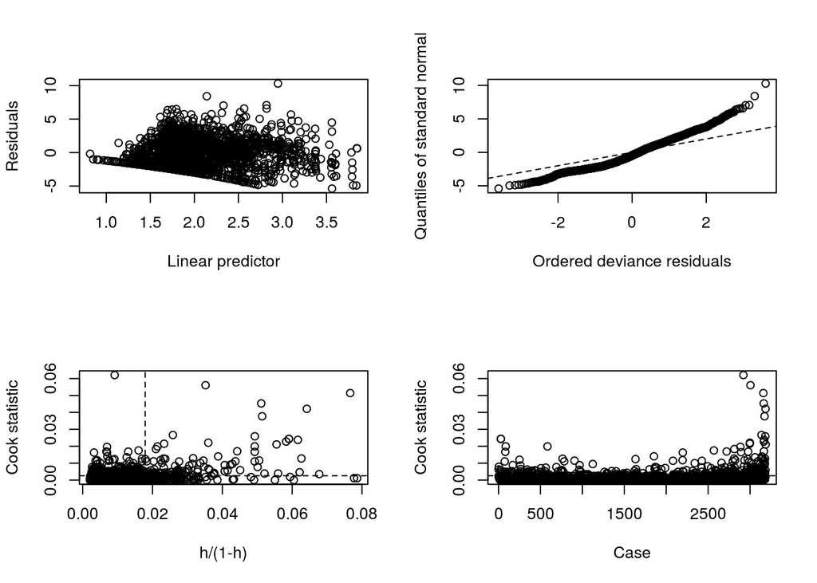

```r
fit <- fit38
glm.diag.plots(fit)
```

Really still not the cleanest diagnsotics. Lot’s of high leverage points, but I know all the data is accurate.

```r
summary(fit)
```

```
##
## Call:
## glm(formula = Count ~ Predator + Day:Predator + Predator:Spot.brightness +
##     Spot.brightness:Predator.number + Predator:Predator.number +
##     Day:Predator:Spot.brightness + Day:Predator:Substrate, family = "quasipoisson",
##     data = guppy_counts)
##
## Deviance Residuals:
##    Min      1Q  Median      3Q     Max
## -5.283  -1.861  -0.473   1.136  10.228
##
## Coefficients:
##                                              Estimate Std. Error t value
## (Intercept)                                 2.584e+00  1.758e-01  14.696
## PredatorR.hartii                           -1.632e+00  2.930e-01  -5.569
## PredatorA.pulchens                         -1.386e+00  2.838e-01  -4.883
## PredatorC.punctata                         -9.637e-01  2.686e-01  -3.588
## PredatorNone:Day                           -6.917e-03  4.199e-04 -16.474
## PredatorR.hartii:Day                       -4.280e-03  3.786e-04 -11.303
## PredatorA.pulchens:Day                      5.091e-05  2.096e-04   0.243
## PredatorC.punctata:Day                      1.745e-04  1.733e-04   1.007
## PredatorNone:Spot.brightness               -8.209e-03  1.141e-02  -0.719
## PredatorR.hartii:Spot.brightness            7.339e-02  1.480e-02   4.958
## PredatorA.pulchens:Spot.brightness          5.264e-02  1.730e-02   3.042
## PredatorC.punctata:Spot.brightness          2.756e-02  1.874e-02   1.471
## Spot.brightness:Predator.number            -6.446e-03  1.492e-03  -4.320
## PredatorR.hartii:Predator.number            7.819e-02  2.649e-02   2.952
## PredatorA.pulchens:Predator.number          5.471e-02  2.051e-02   2.668
## PredatorC.punctata:Predator.number          3.046e-02  1.657e-02   1.839
## PredatorNone:Day:Spot.brightness            3.914e-04  2.215e-05  17.674
## PredatorR.hartii:Day:Spot.brightness        2.493e-04  2.062e-05  12.092
## PredatorA.pulchens:Day:Spot.brightness      4.339e-06  1.579e-05   0.275
## PredatorC.punctata:Day:Spot.brightness     -9.769e-06  1.660e-05  -0.589
## PredatorNone:Day:SubstrateVegetation       -1.514e-04  6.033e-05  -2.509
## PredatorR.hartii:Day:SubstrateVegetation    1.007e-04  6.438e-05   1.564
## PredatorA.pulchens:Day:SubstrateVegetation  5.461e-05  6.864e-05   0.796
## PredatorC.punctata:Day:SubstrateVegetation -2.681e-06  7.012e-05  -0.038
## PredatorNone:Day:SubstrateMud               3.726e-05  6.266e-05   0.595
## PredatorR.hartii:Day:SubstrateMud           3.314e-05  6.443e-05   0.514
## PredatorA.pulchens:Day:SubstrateMud        -4.047e-05  6.892e-05  -0.587
```

[output cut: 25 more lines]

```
## PredatorC.punctata:Day:SubstrateVegetation 0.969504
## PredatorNone:Day:SubstrateMud              0.552189
## PredatorR.hartii:Day:SubstrateMud          0.607084
## PredatorA.pulchens:Day:SubstrateMud        0.557097
## PredatorC.punctata:Day:SubstrateMud        0.384930
## ---
## Signif. codes:  0 '***' 0.001 '**' 0.01 '*' 0.05 '.' 0.1 ' ' 1
##
## (Dispersion parameter for quasipoisson family taken to be 4.051325)
##
##     Null deviance: 19059  on 3185  degrees of freedom
## Residual deviance: 12423  on 3158  degrees of freedom
## AIC: NA
##
## Number of Fisher Scoring iterations: 5
```

Overdispersion reduced a little but still not great. Still no AIC score either. I’ve done everything I know how to now. I think that’s the best I can get it.